# 🏥 EDA — Análisis de Factores de Riesgo de Obesidad

### Proyecto Grupal — Clasificación Multiclase · p7_g1_multiclase

**Autor:** JJ  
**Fecha:** 2026-03-17  
**Dataset:** [ObesityDataSet · Kaggle](https://www.kaggle.com/datasets/aravindpcoder/obesity-or-cvd-risk-classifyregressorcluster)  
**Target:** `NObeyesdad` — 7 niveles de peso corporal

## 📖 ¿Qué es un EDA y para qué sirve?

El **Análisis Exploratorio de Datos (EDA)** es el primer paso de todo proyecto de Machine Learning.  
Antes de entrenar cualquier modelo, necesitamos **entender** los datos:

- ¿Qué hay en el dataset?
- ¿Los datos están limpios o tienen errores?
- ¿Qué variables son importantes?
- ¿Hay patrones o relaciones entre variables?

**Analogía:** El EDA es como hacerle una analítica completa a un paciente antes de diagnosticarle. Puedes saltártelo, pero el diagnóstico será a ciegas.

## 📋 Las 5 Preguntas de Investigación del Equipo

Este EDA responde a las 5 preguntas acordadas por el equipo (Fuente 2 — RequisitosProyecto):

| # | Pregunta | Gráfico |
| --- | --- | --- |
| **P1** | ¿Cuántos registros hay por clase? ¿Están equilibradas? | `countplot` |
| **P2** | ¿Cómo se distribuyen Edad y Peso por nivel de obesidad? ¿Hay solapamiento? | `boxplot` |
| **P3** | ¿Es el antecedente familiar determinante para Obesidad Tipo II y III? | `countplot` con `hue` |
| **P4** | ¿Cómo afectan la actividad física (FAF) y el agua (CH2O) al nivel de obesidad? | `heatmap` / `pairplot` |
| **P5** | ¿Existen outliers o errores en Edad/Peso/Talla? | `scatterplot` Height vs Weight |

## 🗺️ Hoja de Ruta del Notebook

| Bloque | Qué vamos a hacer |
| --- | --- |
| **0** | Importar librerías y cargar datos |
| **1** | Primera inspección del dataset |
| **2** | Análisis de valores nulos |
| **3** | P1 — Distribución del Target (NObeyesdad) |
| **4** | P2 — Segmentación física: Edad y Peso por clase |
| **5** | P3 — Impacto del entorno familiar |
| **6** | Análisis de variables numéricas |
| **7** | Análisis de variables categóricas |
| **8** | P4 — Relación Estilo de Vida y Consumo (Correlaciones) |
| **9** | P5 — Detección de outliers y errores |
| **10** | Conclusiones del EDA y próximos pasos |

> ⚠️ **Importante:** Ejecuta las celdas en orden, de arriba a abajo. Cada celda depende de la anterior.

## 📦 BLOQUE 0 — Importar librerías y cargar el dataset

**¿Qué son las librerías?**  
Son colecciones de funciones ya escritas por otros que podemos reutilizar.

- `pandas` → manipular tablas de datos
- `numpy` → cálculos matemáticos
- `matplotlib` y `seaborn` → crear gráficos
- `warnings` → ocultar avisos que no nos interesan

```python
# ─── Cargar librerías ─────────────────────────────────────────────────────────
import pandas as pd
import numpy as np
import matplotlib.pyplot as plt
import seaborn as sns
import warnings

warnings.filterwarnings('ignore')
sns.set_theme(style='whitegrid', palette='Set2')
plt.rcParams['figure.figsize'] = (10, 5)

print('✅ Librerías cargadas correctamente')
```

```
✅ Librerías cargadas correctamente
```

```python
# ─── Cargar el dataset ────────────────────────────────────────────────────────
# 📌 Ruta acordada por el equipo — no modificar
# Dataset: https://www.kaggle.com/datasets/aravindpcoder/obesity-or-cvd-risk-classifyregressorcluster

df = pd.read_csv('../data/raw/ObesityDataSet.csv')

print(f'✅ Dataset cargado correctamente')
print(f'📊 Dimensiones: {df.shape[0]} filas x {df.shape[1]} columnas')
```

```
✅ Dataset cargado correctamente
📊 Dimensiones: 2111 filas x 17 columnas
```

## 🔍 BLOQUE 1 — Primera inspección del dataset

**Objetivo:** Entender qué hay dentro del dataset sin entrar en detalles todavía.  
Es como abrir la historia clínica de un paciente y ver qué campos tiene antes de leerla en detalle.

**Descripción de las 17 variables del dataset:**

| Variable | Tipo | Descripción |
| --- | --- | --- |
| `Gender` | Categórica | Sexo biológico del individuo (Male / Female) |
| `Age` | Numérica | Edad en años |
| `Height` | Numérica | Altura en metros |
| `Weight` | Numérica | Peso en kilogramos |
| `family_history_with_overweight` | Categórica | ¿Algún familiar ha sufrido sobrepeso? (yes/no) |
| `FAVC` | Categórica | ¿Consume frecuentemente alimentos hipercalóricos? (yes/no) |
| `FCVC` | Numérica | Frecuencia de consumo de verduras (1–3) |
| `NCP` | Numérica | Número de comidas principales al día (1–4) |
| `CAEC` | Categórica | Consumo de alimentos entre comidas (no/Sometimes/Frequently/Always) |
| `SMOKE` | Categórica | ¿Fuma? (yes/no) |
| `CH2O` | Numérica | Consumo diario de agua en litros (1–3) |
| `SCC` | Categórica | ¿Monitoriza su ingesta calórica? (yes/no) |
| `FAF` | Numérica | Frecuencia de actividad física semanal (0–3) |
| `TUE` | Numérica | Tiempo de uso de dispositivos tecnológicos en horas (0–2) |
| `CALC` | Categórica | Frecuencia de consumo de alcohol (no/Sometimes/Frequently/Always) |
| `MTRANS` | Categórica | Medio de transporte habitual (Automobile/Bike/Motorbike/Public_Transportation/Walking) |
| `NObeyesdad` | **TARGET** | Nivel de obesidad clasificado en 7 categorías |

**Preguntas que vamos a responder:**

- ¿Cuántas filas y columnas tiene?
- ¿Qué tipo de dato tiene cada columna?
- ¿Las primeras filas tienen sentido?

```python
# Ver las primeras 5 filas del dataset
# Esto nos da una idea visual de cómo están organizados los datos
df.head()
```

|  | Gender | Age | Height | Weight | family_history_with_overweight | FAVC | FCVC | NCP | CAEC | SMOKE | CH2O | SCC | FAF | TUE | CALC | MTRANS | NObeyesdad |
| --- | --- | --- | --- | --- | --- | --- | --- | --- | --- | --- | --- | --- | --- | --- | --- | --- | --- |
| 0 | Female | 21.0 | 1.62 | 64.0 | yes | no | 2.0 | 3.0 | Sometimes | no | 2.0 | no | 0.0 | 1.0 | no | Public_Transportation | Normal_Weight |
| 1 | Female | 21.0 | 1.52 | 56.0 | yes | no | 3.0 | 3.0 | Sometimes | yes | 3.0 | yes | 3.0 | 0.0 | Sometimes | Public_Transportation | Normal_Weight |
| 2 | Male | 23.0 | 1.80 | 77.0 | yes | no | 2.0 | 3.0 | Sometimes | no | 2.0 | no | 2.0 | 1.0 | Frequently | Public_Transportation | Normal_Weight |
| 3 | Male | 27.0 | 1.80 | 87.0 | no | no | 3.0 | 3.0 | Sometimes | no | 2.0 | no | 2.0 | 0.0 | Frequently | Walking | Overweight_Level_I |
| 4 | Male | 22.0 | 1.78 | 89.8 | no | no | 2.0 | 1.0 | Sometimes | no | 2.0 | no | 0.0 | 0.0 | Sometimes | Public_Transportation | Overweight_Level_II |

```python
# Información general del dataset
# 'object' = texto | 'float64/int64' = número
print('ℹ️ Información del dataset:')
df.info()
```

```
ℹ️ Información del dataset:
<class 'pandas.DataFrame'>
RangeIndex: 2111 entries, 0 to 2110
Data columns (total 17 columns):
 #   Column                          Non-Null Count  Dtype
---  ------                          --------------  -----
 0   Gender                          2111 non-null   str
 1   Age                             2111 non-null   float64
 2   Height                          2111 non-null   float64
 3   Weight                          2111 non-null   float64
 4   family_history_with_overweight  2111 non-null   str
 5   FAVC                            2111 non-null   str
 6   FCVC                            2111 non-null   float64
 7   NCP                             2111 non-null   float64
 8   CAEC                            2111 non-null   str
 9   SMOKE                           2111 non-null   str
 10  CH2O                            2111 non-null   float64
 11  SCC                             2111 non-null   str
 12  FAF                             2111 non-null   float64
 13  TUE                             2111 non-null   float64
 14  CALC                            2111 non-null   str
 15  MTRANS                          2111 non-null   str
 16  NObeyesdad                      2111 non-null   str
dtypes: float64(8), str(9)
memory usage: 280.5 KB
```

```python
# Estadísticas descriptivas de las columnas numéricas
# count=cuántos valores hay | mean=promedio | std=dispersión | min/max=extremos
df.describe()
```

|  | Age | Height | Weight | FCVC | NCP | CH2O | FAF | TUE |
| --- | --- | --- | --- | --- | --- | --- | --- | --- |
| count | 2111.000000 | 2111.000000 | 2111.000000 | 2111.000000 | 2111.000000 | 2111.000000 | 2111.000000 | 2111.000000 |
| mean | 24.312600 | 1.701677 | 86.586058 | 2.419043 | 2.685628 | 2.008011 | 1.010298 | 0.657866 |
| std | 6.345968 | 0.093305 | 26.191172 | 0.533927 | 0.778039 | 0.612953 | 0.850592 | 0.608927 |
| min | 14.000000 | 1.450000 | 39.000000 | 1.000000 | 1.000000 | 1.000000 | 0.000000 | 0.000000 |
| 25% | 19.947192 | 1.630000 | 65.473343 | 2.000000 | 2.658738 | 1.584812 | 0.124505 | 0.000000 |
| 50% | 22.777890 | 1.700499 | 83.000000 | 2.385502 | 3.000000 | 2.000000 | 1.000000 | 0.625350 |
| 75% | 26.000000 | 1.768464 | 107.430682 | 3.000000 | 3.000000 | 2.477420 | 1.666678 | 1.000000 |
| max | 61.000000 | 1.980000 | 173.000000 | 3.000000 | 4.000000 | 3.000000 | 3.000000 | 2.000000 |

```python
# Ver el nombre de todas las columnas disponibles
print('📋 Columnas del dataset:')
print(df.columns.tolist())
```

```
📋 Columnas del dataset:
['Gender', 'Age', 'Height', 'Weight', 'family_history_with_overweight', 'FAVC', 'FCVC', 'NCP', 'CAEC', 'SMOKE', 'CH2O', 'SCC', 'FAF', 'TUE', 'CALC', 'MTRANS', 'NObeyesdad']
```

## 🕳️ BLOQUE 2 — Análisis de valores nulos

**¿Qué es un valor nulo?**  
Un valor nulo (NaN = Not a Number) es una celda vacía en nuestros datos.  
Ocurre cuando la información no estaba disponible o no se registró.

**¿Por qué importa?**  
Los modelos de ML no pueden trabajar con valores vacíos. Tenemos que decidir qué hacer con ellos:

- **Eliminar** la fila o columna
- **Rellenar** con un valor (media, mediana, moda)

**Regla general:**

- Si una columna tiene `> 40% nulos` → considerar eliminarla
- Si tiene `< 40% nulos` → rellenar (imputar)

> 📌 **Nota:** El dataset ObesityDataSet es conocido por estar bastante limpio. Si no hay nulos, lo confirmamos y seguimos.

```python
# Contar valores nulos por columna
nulos = df.isnull().sum()
pct_nulos = (nulos / len(df) * 100).round(2)

resumen_nulos = pd.DataFrame({
    'Nulos': nulos,
    '% Nulos': pct_nulos
})
print('🕳️ Valores nulos por columna:')
print(resumen_nulos[resumen_nulos['Nulos'] > 0] if nulos.sum() > 0 else '✅ No hay valores nulos en el dataset')
```

```
🕳️ Valores nulos por columna:
✅ No hay valores nulos en el dataset
```

```python
# Visualizar los nulos con un heatmap (solo si hay nulos)
if df.isnull().sum().sum() > 0:
    plt.figure(figsize=(14, 4))
    sns.heatmap(df.isnull(), cbar=False, yticklabels=False, cmap='viridis')
    plt.title('Mapa de valores nulos')
    plt.tight_layout()
    plt.show()
else:
    print('✅ Sin valores nulos — no se genera heatmap')
```

```
✅ Sin valores nulos — no se genera heatmap
```

```python
# ─── DECISIÓN: Qué columnas eliminar ─────────────────────────────────────────
# 📌 ACCIÓN: Revisa y ajusta la lista según tus conclusiones del análisis de nulos
# Ejemplo: columnas con > 40% nulos o que no aporten información al modelo

columnas_a_eliminar = []  # Añade aquí las columnas a eliminar, ej: ['col1', 'col2']

if columnas_a_eliminar:
    df.drop(columns=columnas_a_eliminar, inplace=True)
    print(f'🗑️ Columnas eliminadas: {columnas_a_eliminar}')
    print(f'📊 Nuevas dimensiones: {df.shape}')
else:
    print('ℹ️ No se ha eliminado ninguna columna en este paso')
```

```
ℹ️ No se ha eliminado ninguna columna en este paso
```

## 🎯 BLOQUE 3 — P1: Distribución del Target (NObeyesdad)

**Pregunta de investigación 1:**

> ¿Cuántos registros hay por cada una de las 7 clases? ¿Están equilibradas o hay alguna clase minoritaria?

**Los 7 valores del Target:**

| Clase | Descripción | Criterio aproximado (IMC) |
| --- | --- | --- |
| `Insufficient_Weight` | Peso insuficiente | IMC < 18.5 |
| `Normal_Weight` | Peso normal | IMC 18.5–24.9 |
| `Overweight_Level_I` | Sobrepeso Nivel I | IMC 25–27.4 |
| `Overweight_Level_II` | Sobrepeso Nivel II | IMC 27.5–29.9 |
| `Obesity_Type_I` | Obesidad Tipo I | IMC 30–34.9 |
| `Obesity_Type_II` | Obesidad Tipo II | IMC 35–39.9 |
| `Obesity_Type_III` | Obesidad Tipo III (mórbida) | IMC ≥ 40 |

**Distribución conocida del dataset:**  
`Insufficient_Weight`: 272 · `Normal_Weight`: 287 · `Overweight_I`: 290 · `Overweight_II`: 290 · `Obesity_II`: 297 · `Obesity_III`: 324 · `Obesity_I`: 351

**Gráfico sugerido:** `sns.countplot`

```python
# ─── Conteo de registros por clase ────────────────────────────────────────────
conteo_target = df['NObeyesdad'].value_counts()
print('📊 Registros por clase (NObeyesdad):')
print(conteo_target)
print(f'\nTotal de registros: {len(df)}')
print(f'Número de clases: {df["NObeyesdad"].nunique()}')
```

```
📊 Registros por clase (NObeyesdad):
NObeyesdad
Obesity_Type_I         351
Obesity_Type_III       324
Obesity_Type_II        297
Overweight_Level_I     290
Overweight_Level_II    290
Normal_Weight          287
Insufficient_Weight    272
Name: count, dtype: int64

Total de registros: 2111
Número de clases: 7
```

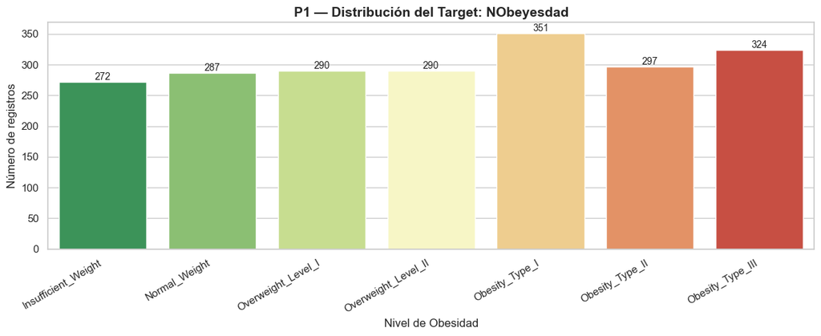

```
⚖️ Ratio max/min entre clases: 1.29
✅ Dataset EQUILIBRADO
```

```python
# ─── Gráfico: countplot del target ────────────────────────────────────────────
# Orden lógico de menor a mayor nivel de obesidad
orden_clases = [
    'Insufficient_Weight', 'Normal_Weight',
    'Overweight_Level_I', 'Overweight_Level_II',
    'Obesity_Type_I', 'Obesity_Type_II', 'Obesity_Type_III'
]

plt.figure(figsize=(12, 5))
ax = sns.countplot(data=df, x='NObeyesdad', order=orden_clases, palette='RdYlGn_r')

# Añadir etiquetas con los conteos encima de cada barra
for p in ax.patches:
    ax.annotate(f'{int(p.get_height())}',
                (p.get_x() + p.get_width() / 2., p.get_height()),
                ha='center', va='bottom', fontsize=10)

plt.title('P1 — Distribución del Target: NObeyesdad', fontsize=14, fontweight='bold')
plt.xlabel('Nivel de Obesidad')
plt.ylabel('Número de registros')
plt.xticks(rotation=30, ha='right')
plt.tight_layout()
plt.show()

# Evaluación de equilibrio
max_clase = conteo_target.max()
min_clase = conteo_target.min()
ratio = max_clase / min_clase
print(f'\n⚖️ Ratio max/min entre clases: {ratio:.2f}')
print('✅ Dataset EQUILIBRADO' if ratio < 1.5 else '⚠️ Dataset LEVEMENTE DESEQUILIBRADO — considerar técnicas de balanceo')
```

## 📊 BLOQUE 4 — P2: Segmentación Física — Edad y Peso por clase

**Pregunta de investigación 2:**

> ¿Cómo se distribuyen la Edad y el Peso a través de los niveles de obesidad? ¿Hay solapamiento entre las clases?

**¿Por qué importa para el modelo?**  
Si las clases se solapan mucho en Peso y Edad, el modelo tendrá dificultades para distinguirlas.  
Si están bien separadas, serán features muy discriminativas.

**Gráfico sugerido:** `sns.boxplot(x='NObeyesdad', y='Weight', data=df)`

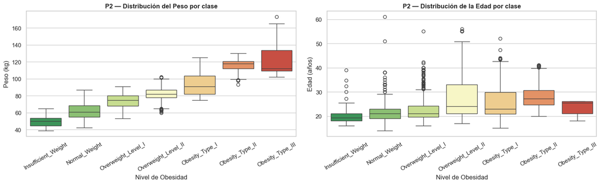

```python
# ─── Boxplot: Peso por nivel de obesidad ──────────────────────────────────────
fig, axes = plt.subplots(1, 2, figsize=(16, 5))

# Peso
sns.boxplot(
    data=df,
    x='NObeyesdad', y='Weight',
    order=orden_clases,
    palette='RdYlGn_r',
    ax=axes[0]
)
axes[0].set_title('P2 — Distribución del Peso por clase', fontweight='bold')
axes[0].set_xlabel('Nivel de Obesidad')
axes[0].set_ylabel('Peso (kg)')
axes[0].tick_params(axis='x', rotation=30)

# Edad
sns.boxplot(
    data=df,
    x='NObeyesdad', y='Age',
    order=orden_clases,
    palette='RdYlGn_r',
    ax=axes[1]
)
axes[1].set_title('P2 — Distribución de la Edad por clase', fontweight='bold')
axes[1].set_xlabel('Nivel de Obesidad')
axes[1].set_ylabel('Edad (años)')
axes[1].tick_params(axis='x', rotation=30)

plt.tight_layout()
plt.show()
```

```python
# ─── Estadísticas de Peso y Edad por clase ────────────────────────────────────
print('📊 Estadísticas de Peso (kg) por clase:')
print(df.groupby('NObeyesdad')['Weight'].describe().round(2))
print()
print('📊 Estadísticas de Edad (años) por clase:')
print(df.groupby('NObeyesdad')['Age'].describe().round(2))
```

```
📊 Estadísticas de Peso (kg) por clase:
                     count    mean    std    min     25%     50%     75%  \
NObeyesdad
Insufficient_Weight  272.0   49.91   6.01   39.0   44.66   50.00   53.67
Normal_Weight        287.0   62.16   9.30   42.3   55.00   61.00   68.50
Obesity_Type_I       351.0   92.87  11.49   75.0   82.14   90.74  103.74
Obesity_Type_II      297.0  115.31   8.02   93.0  112.01  117.79  120.81
Obesity_Type_III     324.0  120.94  15.53  102.0  109.49  112.05  133.50
Overweight_Level_I   290.0   74.27   8.47   53.0   68.15   75.00   80.00
Overweight_Level_II  290.0   82.09   8.45   60.0   78.03   82.00   86.85

                       max
NObeyesdad
Insufficient_Weight   65.0
Normal_Weight         87.0
Obesity_Type_I       125.0
Obesity_Type_II      130.0
Obesity_Type_III     173.0
Overweight_Level_I    91.0
Overweight_Level_II  102.0

📊 Estadísticas de Edad (años) por clase:
                     count   mean   std   min    25%    50%    75%   max
NObeyesdad
Insufficient_Weight  272.0  19.78  2.67  16.0  18.00  19.24  21.00  39.0
Normal_Weight        287.0  21.74  5.10  14.0  19.00  21.00  23.00  61.0
Obesity_Type_I       351.0  25.88  7.76  15.0  20.88  22.98  29.78  52.0
Obesity_Type_II      297.0  28.23  4.87  20.0  24.58  27.19  30.72  41.0
Obesity_Type_III     324.0  23.50  2.76  18.0  21.02  25.37  26.00  26.0
Overweight_Level_I   290.0  23.42  6.13  16.0  19.62  21.05  24.22  55.0
Overweight_Level_II  290.0  27.00  8.06  17.0  21.00  24.00  33.00  56.0
```

## 👨‍👩‍👧 BLOQUE 5 — P3: Impacto del Entorno Familiar

**Pregunta de investigación 3:**

> ¿Es el antecedente familiar (`family_history_with_overweight`) un factor determinante para las clases de Obesidad Tipo II y III?

**Contexto clínico:**  
La predisposición genética y los hábitos familiares son factores de riesgo reconocidos para la obesidad.  
Si la variable `family_history_with_overweight` discrimina bien las clases más graves, será una feature clave para el modelo.

**Gráfico sugerido:** `sns.countplot(x='NObeyesdad', hue='family_history_with_overweight')`

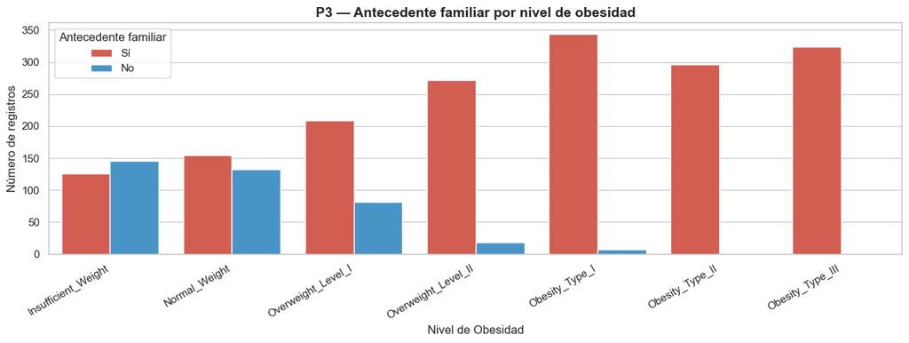

```python
# ─── Countplot: Antecedente familiar por nivel de obesidad ────────────────────
plt.figure(figsize=(13, 5))
ax = sns.countplot(
    data=df,
    x='NObeyesdad',
    hue='family_history_with_overweight',
    order=orden_clases,
    palette={'yes': '#e74c3c', 'no': '#3498db'}
)
plt.title('P3 — Antecedente familiar por nivel de obesidad', fontsize=14, fontweight='bold')
plt.xlabel('Nivel de Obesidad')
plt.ylabel('Número de registros')
plt.xticks(rotation=30, ha='right')
plt.legend(title='Antecedente familiar', labels=['Sí', 'No'])
plt.tight_layout()
plt.show()
```

```python
# ─── Proporción de antecedente familiar por clase ─────────────────────────────
tabla_cruzada = pd.crosstab(
    df['NObeyesdad'],
    df['family_history_with_overweight'],
    normalize='index'
).round(3) * 100

tabla_cruzada.columns = ['Sin antecedente (%)', 'Con antecedente (%)']
tabla_cruzada = tabla_cruzada.reindex(orden_clases)
print('📊 % de antecedente familiar por clase:')
print(tabla_cruzada)
```

```
📊 % de antecedente familiar por clase:
                     Sin antecedente (%)  Con antecedente (%)
NObeyesdad
Insufficient_Weight                 53.7                 46.3
Normal_Weight                       46.0                 54.0
Overweight_Level_I                  27.9                 72.1
Overweight_Level_II                  6.2                 93.8
Obesity_Type_I                       2.0                 98.0
Obesity_Type_II                      0.3                 99.7
Obesity_Type_III                     0.0                100.0
```

## 📈 BLOQUE 6 — Análisis de variables numéricas

**Objetivo:** Entender cómo se distribuye cada variable numérica del dataset.  
Detectar sesgos, rangos anómalos o distribuciones inesperadas.

**Variables numéricas del dataset:**

- `Age`, `Height`, `Weight` → datos antropométricos
- `FCVC` → frecuencia consumo verduras (1–3)
- `NCP` → número de comidas principales (1–4)
- `CH2O` → litros de agua/día (1–3)
- `FAF` → frecuencia actividad física (0–3)
- `TUE` → horas dispositivos tecnológicos (0–2)

```python
# ─── Definir variables numéricas ──────────────────────────────────────────────
vars_numericas = ['Age', 'Height', 'Weight', 'FCVC', 'NCP', 'CH2O', 'FAF', 'TUE']

print('📋 Variables numéricas seleccionadas:')
print(vars_numericas)
```

```
📋 Variables numéricas seleccionadas:
['Age', 'Height', 'Weight', 'FCVC', 'NCP', 'CH2O', 'FAF', 'TUE']
```

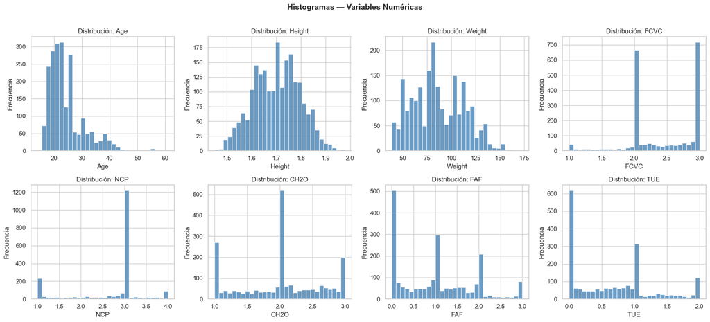

```python
# ─── Histogramas de todas las variables numéricas ─────────────────────────────
# Un histograma muestra cuántas muestras hay en cada rango de valores
# Ideal: distribución en forma de campana (normal)
# Si está muy sesgada hacia un lado, puede indicar outliers

fig, axes = plt.subplots(2, 4, figsize=(18, 8))
axes = axes.flatten()

for i, var in enumerate(vars_numericas):
    axes[i].hist(df[var].dropna(), bins=30, color='steelblue', edgecolor='white', alpha=0.8)
    axes[i].set_title(f'Distribución: {var}')
    axes[i].set_xlabel(var)
    axes[i].set_ylabel('Frecuencia')

plt.suptitle('Histogramas — Variables Numéricas', fontsize=14, fontweight='bold', y=1.01)
plt.tight_layout()
plt.show()
```

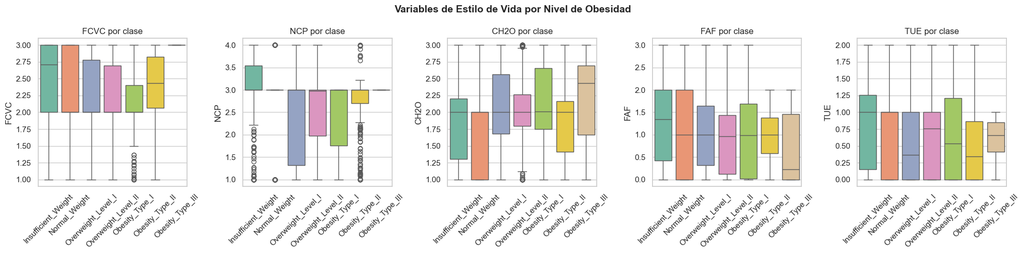

```python
# ─── Boxplots comparativos por nivel de obesidad ──────────────────────────────
# Ver si las variables numéricas diferencian bien entre clases
vars_lifestyle = ['FCVC', 'NCP', 'CH2O', 'FAF', 'TUE']

fig, axes = plt.subplots(1, len(vars_lifestyle), figsize=(20, 5))

for i, var in enumerate(vars_lifestyle):
    sns.boxplot(
        data=df, x='NObeyesdad', y=var,
        order=orden_clases,
        palette='Set2',
        ax=axes[i]
    )
    axes[i].set_title(f'{var} por clase')
    axes[i].set_xlabel('')
    axes[i].tick_params(axis='x', rotation=45)

plt.suptitle('Variables de Estilo de Vida por Nivel de Obesidad', fontsize=14, fontweight='bold')
plt.tight_layout()
plt.show()
```

## 🌍 BLOQUE 7 — Análisis de variables categóricas

**Variables categóricas del dataset:**

- `Gender` → Sexo (Male/Female)
- `family_history_with_overweight` → ya analizado en P3
- `FAVC` → Consumo frecuente alimentos hipercalóricos (yes/no)
- `CAEC` → Consumo entre comidas (no/Sometimes/Frequently/Always)
- `SMOKE` → Fuma (yes/no)
- `SCC` → Monitoriza calorías (yes/no)
- `CALC` → Consumo de alcohol (no/Sometimes/Frequently/Always)
- `MTRANS` → Medio de transporte (5 opciones)

**Objetivo:** Ver si estas variables presentan patrones distintos según el nivel de obesidad.

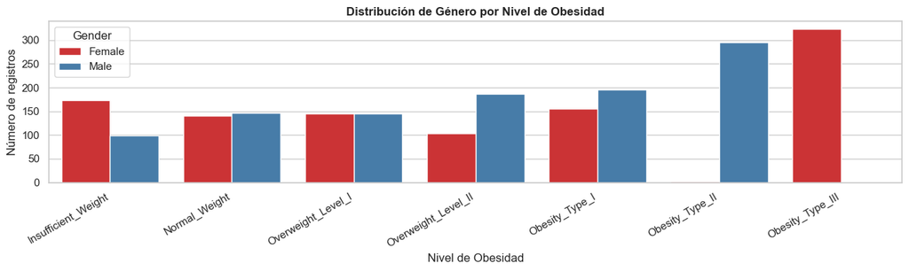

```python
# ─── Distribución del género por clase de obesidad ────────────────────────────
plt.figure(figsize=(13, 4))
sns.countplot(
    data=df,
    x='NObeyesdad',
    hue='Gender',
    order=orden_clases,
    palette='Set1'
)
plt.title('Distribución de Género por Nivel de Obesidad', fontweight='bold')
plt.xlabel('Nivel de Obesidad')
plt.ylabel('Número de registros')
plt.xticks(rotation=30, ha='right')
plt.tight_layout()
plt.show()
```

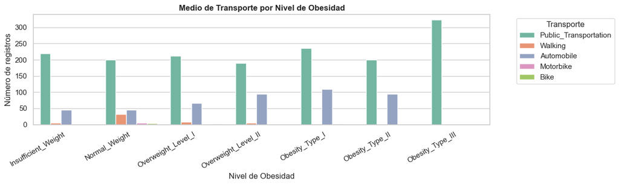

```python
# ─── Distribución del medio de transporte ─────────────────────────────────────
# MTRANS puede correlacionar con sedentarismo y nivel de obesidad
plt.figure(figsize=(13, 4))
sns.countplot(
    data=df,
    x='NObeyesdad',
    hue='MTRANS',
    order=orden_clases
)
plt.title('Medio de Transporte por Nivel de Obesidad', fontweight='bold')
plt.xlabel('Nivel de Obesidad')
plt.ylabel('Número de registros')
plt.xticks(rotation=30, ha='right')
plt.legend(title='Transporte', bbox_to_anchor=(1.05, 1), loc='upper left')
plt.tight_layout()
plt.show()
```

```python
# ─── Agregar los gráficos categóricos que consideres necesarios ───────────────
# Sugerencias: FAVC, CAEC, CALC, SMOKE, SCC
# Ejemplo:
# sns.countplot(data=df, x='NObeyesdad', hue='FAVC', order=orden_clases)
```

## 🔥 BLOQUE 8 — P4: Relación Estilo de Vida y Consumo (Correlaciones)

**Pregunta de investigación 4:**

> ¿Cómo afectan la actividad física (`FAF`) y el consumo de agua (`CH2O`) al nivel de obesidad?

**¿Qué es la correlación?**  
Mide cuánto se relacionan dos variables numéricas entre sí.

- Correlación `+1` → relación perfecta positiva
- Correlación `-1` → relación perfecta negativa
- Correlación `0` → no hay relación

**¿Para qué sirve en ML?**

- Identificar qué variables tienen más relación con el target
- Detectar variables muy correlacionadas entre sí (redundantes)

**Gráfico sugerido:** `sns.heatmap` (matriz de correlación) o `sns.pairplot`

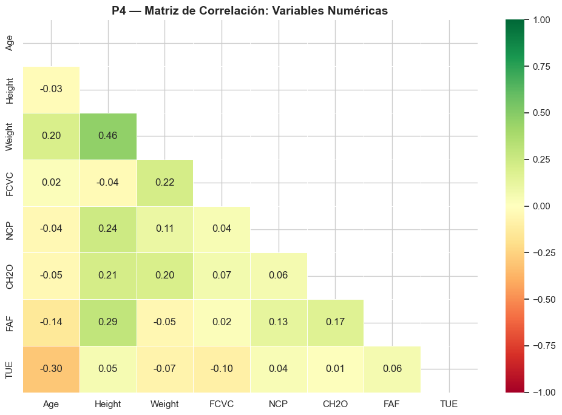

```python
# ─── Heatmap de correlación entre variables numéricas ─────────────────────────
# Solo calculamos correlación entre columnas numéricas
vars_corr = df[vars_numericas].corr()

plt.figure(figsize=(10, 7))
mask = np.triu(np.ones_like(vars_corr, dtype=bool))  # Ocultar triángulo superior (redundante)
sns.heatmap(
    vars_corr,
    mask=mask,
    annot=True,
    fmt='.2f',
    cmap='RdYlGn',
    center=0,
    vmin=-1, vmax=1,
    linewidths=0.5
)
plt.title('P4 — Matriz de Correlación: Variables Numéricas', fontsize=14, fontweight='bold')
plt.tight_layout()
plt.show()
```

```
📊 Correlación (absoluta) de cada variable numérica con el Target:
Weight    0.388
Age       0.236
FAF       0.130
CH2O      0.109
NCP       0.093
TUE       0.069
Height    0.039
FCVC      0.019
Name: NObeyesdad_encoded, dtype: float64
```

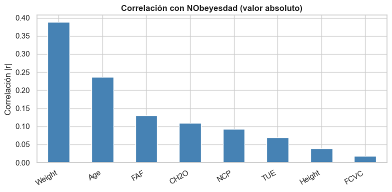

```python
# ─── Correlación con el Target (codificado numéricamente) ─────────────────────
# Codificamos el target para poder calcular su correlación con las features numéricas
from sklearn.preprocessing import LabelEncoder

le = LabelEncoder()
df['NObeyesdad_encoded'] = le.fit_transform(df['NObeyesdad'])

correlacion_target = df[vars_numericas + ['NObeyesdad_encoded']].corr()['NObeyesdad_encoded'].drop('NObeyesdad_encoded')
correlacion_target = correlacion_target.abs().sort_values(ascending=False)

print('📊 Correlación (absoluta) de cada variable numérica con el Target:')
print(correlacion_target.round(3))

# Gráfico de barras de correlación con el target
plt.figure(figsize=(8, 4))
correlacion_target.plot(kind='bar', color='steelblue', edgecolor='white')
plt.title('Correlación con NObeyesdad (valor absoluto)', fontweight='bold')
plt.ylabel('Correlación |r|')
plt.xticks(rotation=30, ha='right')
plt.tight_layout()
plt.show()
```

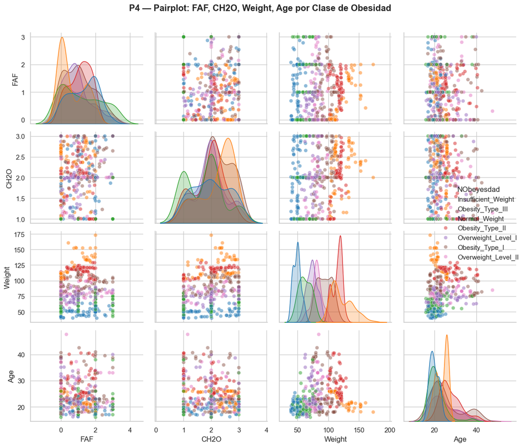

```python
# ─── Pairplot: FAF y CH2O coloreados por clase ───────────────────────────────
# Ver si la actividad física y el agua separan visualmente las clases
# ⚠️ Este gráfico puede tardar unos segundos

muestra = df.sample(n=500, random_state=42)  # Muestra para agilizar el render

sns.pairplot(
    muestra[['FAF', 'CH2O', 'Weight', 'Age', 'NObeyesdad']],
    hue='NObeyesdad',
    palette='tab10',
    diag_kind='kde',
    plot_kws={'alpha': 0.5}
)
plt.suptitle('P4 — Pairplot: FAF, CH2O, Weight, Age por Clase de Obesidad', y=1.01, fontweight='bold')
plt.tight_layout()
plt.show()
```

## 🎯 BLOQUE 9 — P5: Detección de Outliers y Errores

**Pregunta de investigación 5:**

> ¿Existen valores de Edad o Peso que parezcan errores de entrada de datos?

**¿Qué es un outlier?**  
Es un valor extremo muy alejado del resto.  
Por ejemplo: una persona con Height=3.5m o Weight=5kg son probablemente errores de entrada.

**¿Por qué importa?**  
Los outliers pueden distorsionar el modelo, haciéndolo aprender de casos excepcionales en lugar de la norma.

**Métodos que usaremos:**

- **Scatterplot** Height vs Weight (gráfico sugerido en los requisitos)
- **Boxplots** de variables clave
- **Método IQR:** outlier si está fuera de `[Q1 - 1.5×IQR, Q3 + 1.5×IQR]`

**Gráfico sugerido:** `sns.scatterplot` entre Height y Weight

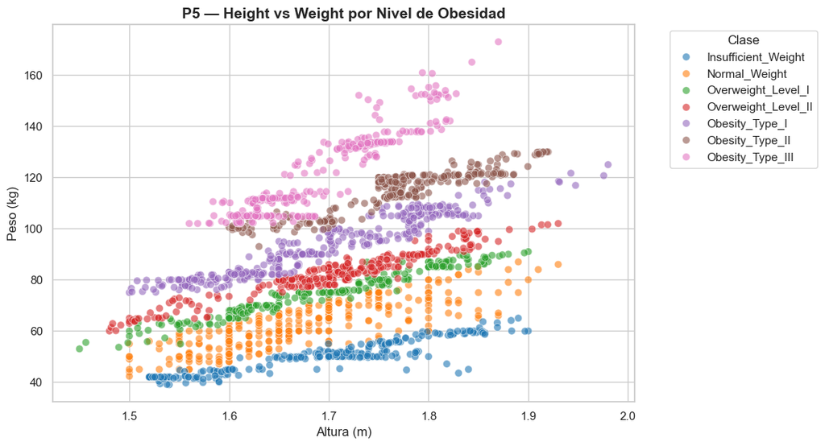

```python
# ─── Scatterplot: Height vs Weight coloreado por clase ────────────────────────
plt.figure(figsize=(11, 6))
sns.scatterplot(
    data=df,
    x='Height', y='Weight',
    hue='NObeyesdad',
    hue_order=orden_clases,
    palette='tab10',
    alpha=0.6,
    s=50
)
plt.title('P5 — Height vs Weight por Nivel de Obesidad', fontsize=14, fontweight='bold')
plt.xlabel('Altura (m)')
plt.ylabel('Peso (kg)')
plt.legend(title='Clase', bbox_to_anchor=(1.05, 1), loc='upper left')
plt.tight_layout()
plt.show()
```

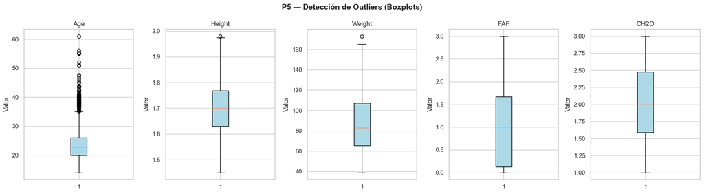

```python
# ─── Boxplots para detectar outliers en variables clave ───────────────────────
vars_outlier = ['Age', 'Height', 'Weight', 'FAF', 'CH2O']

fig, axes = plt.subplots(1, len(vars_outlier), figsize=(18, 5))
for i, var in enumerate(vars_outlier):
    axes[i].boxplot(df[var].dropna(), patch_artist=True,
                    boxprops=dict(facecolor='lightblue'))
    axes[i].set_title(var)
    axes[i].set_ylabel('Valor')

plt.suptitle('P5 — Detección de Outliers (Boxplots)', fontsize=14, fontweight='bold')
plt.tight_layout()
plt.show()
```

```python
# ─── Cuantificar outliers con el Método IQR ───────────────────────────────────
print('📊 Outliers detectados por Método IQR:')
print(f'{"Variable":<12} {"Q1":>8} {"Q3":>8} {"IQR":>8} {"Límite Inf":>12} {"Límite Sup":>12} {"Nº Outliers":>12}')
print('-' * 80)

for var in vars_outlier:
    Q1 = df[var].quantile(0.25)
    Q3 = df[var].quantile(0.75)
    IQR = Q3 - Q1
    lim_inf = Q1 - 1.5 * IQR
    lim_sup = Q3 + 1.5 * IQR
    n_outliers = ((df[var] < lim_inf) | (df[var] > lim_sup)).sum()
    print(f'{var:<12} {Q1:>8.2f} {Q3:>8.2f} {IQR:>8.2f} {lim_inf:>12.2f} {lim_sup:>12.2f} {n_outliers:>12}')
```

```
📊 Outliers detectados por Método IQR:
Variable           Q1       Q3      IQR   Límite Inf   Límite Sup  Nº Outliers
--------------------------------------------------------------------------------
Age             19.95    26.00     6.05        10.87        35.08          168
Height           1.63     1.77     0.14         1.42         1.98            1
Weight          65.47   107.43    41.96         2.54       170.37            1
FAF              0.12     1.67     1.54        -2.19         3.98            0
CH2O             1.58     2.48     0.89         0.25         3.82            0
```

```python
# ─── DECISIÓN: Tratamiento de outliers ───────────────────────────────────────
# 📌 ACCIÓN: Completa esta celda con las decisiones del equipo tras el análisis
# Opciones:
#   1. Eliminar filas con outliers: df = df[df['Weight'] < lim_sup_weight]
#   2. Imputar con mediana: df.loc[df['Age'] > lim_sup_age, 'Age'] = df['Age'].median()
#   3. Mantenerlos si son valores reales (no errores de entrada)

print('📌 Pendiente decisión del equipo sobre tratamiento de outliers')
print('Opciones: eliminar · imputar · mantener')
```

```
📌 Pendiente decisión del equipo sobre tratamiento de outliers
Opciones: eliminar · imputar · mantener
```

## ✅ BLOQUE 10 — Conclusiones del EDA y Próximos Pasos

### 📋 Resumen para el README.md del equipo *(pendiente completar)*

[output not shown]

### 📌 Plantilla de Conclusiones (rellenar tras el análisis)

[output not shown]

```python
# ─── Resumen final del dataset tras el EDA ────────────────────────────────────
print('📊 Estado del dataset tras el EDA:')
print(f'   Filas:    {df.shape[0]}')
print(f'   Columnas: {df.shape[1]}')
print(f'   Nulos:    {df.isnull().sum().sum()}')
print(f'   Clases:   {df["NObeyesdad"].nunique()}')
print()
print('📊 Distribución final del Target:')
print(df['NObeyesdad'].value_counts())
```

```
📊 Estado del dataset tras el EDA:
   Filas:    2111
   Columnas: 18
   Nulos:    0
   Clases:   7

📊 Distribución final del Target:
NObeyesdad
Obesity_Type_I         351
Obesity_Type_III       324
Obesity_Type_II        297
Overweight_Level_I     290
Overweight_Level_II    290
Normal_Weight          287
Insufficient_Weight    272
Name: count, dtype: int64
```

```python
# ─── Guardar el dataset limpio para el siguiente notebook ─────────────────────
# Este CSV limpio será el punto de partida del notebook de preprocesamiento y modelado
# Guardar en la carpeta processed (acordado por el equipo)

# 📌 Eliminar columna auxiliar de encoding antes de guardar
if 'NObeyesdad_encoded' in df.columns:
    df.drop(columns=['NObeyesdad_encoded'], inplace=True)

ruta_salida = '../data/processed/ObesityDataSet_clean.csv'
df.to_csv(ruta_salida, index=False)

print(f'✅ Dataset limpio guardado en: {ruta_salida}')
print(f'📊 Dimensiones finales: {df.shape[0]} filas x {df.shape[1]} columnas')
```

```
✅ Dataset limpio guardado en: ../data/processed/ObesityDataSet_clean.csv
📊 Dimensiones finales: 2111 filas x 17 columnas
```